# Practical Machine Learning Project

Myles Joyce

9/26/2020

### Background

As the use of wearable fitness devices increases, the data regarding people’s activity levels has become more accessible. Usually, this data is used to quantify how much of a particular activity that the wearers perform but rarely how well said activity is performed. This performance value could potentially be quantified using accelerometer data from the belt, forearm, arm, and dumbbell of 6 participants who perform barbell lifts both in correct and incorrect fashion.

### Data

**Training Data**: https://d396qusza40orc.cloudfront.net/predmachlearn/pml-training.csv  
**Test Data**: https://d396qusza40orc.cloudfront.net/predmachlearn/pml-testing.csv

More information about the data can be found here: http://groupware.les.inf.puc-rio.br/har  
“Six young health participants were asked to perform one set of 10 repetitions of the Unilateral Dumbbell Biceps Curl in five different fashions: exactly according to the specification (Class A), throwing the elbows to the front (Class B), lifting the dumbbell only halfway (Class C), lowering the dumbbell only halfway (Class D) and throwing the hips to the front (Class E).”

### Purpose

- To predict the manner in which the participants performed the exercise. This is the “classE” variable. This is to be done through model building, cross validation, and out-of-sample error calculation.

### Package and Data Loading

```r
setwd(getwd())
library(caret)
library(randomForest)
```

```r
library(rpart)
library(rpart.plot)
library(gbm)
library(repmis)
library(corrplot)
library(rattle)
library(RGtk2)
```

[output not shown]

[output not shown]

[output not shown]

[output not shown]

```r
trUrl <- "http://d396qusza40orc.cloudfront.net/predmachlearn/pml-training.csv"
teUrl <- "http://d396qusza40orc.cloudfront.net/predmachlearn/pml-testing.csv"
train <- read.csv(url(trUrl), na.strings=c("NA","#DIV/0!",""))
test <- read.csv(url(teUrl), na.strings=c("NA","#DIV/0!",""))
```

### Cleaning the Data

Removing the first 8 variables which seem to be irrelevant.

```r
train <- train[, -c(1:8)]
```

Removing any columns that are more than 50% NA’s.

```r
train2 <- train
for(i in 1:length(train)) {
        if( sum( is.na( train[, i] ) ) /nrow(train) >= .5 ) {
        for(j in 1:length(train)) {
            if( length( grep(names(train[i]), names(train2)[j]) ) ==1)  {
                train2 <- train2[ , -j]
            }
        }
    }
}
train <- train2
```

Applying these changes to the test set.

```r
test <- test[colnames(train[,-52])]
```

### Partioning Data

Splitting the data 65% into a training set and 35% into a testing set. Also, setting the seed.

```r
set.seed(1110)
in_train <- createDataPartition(y=train$classe, p=0.65, list=FALSE)
my_train <- train[in_train, ]
my_test <- train[-in_train, ]
dim(my_train)
```

```
## [1] 12757    52
```

```r
dim(my_test)
```

```
## [1] 6865   52
```

The dimensions check out, so now can start modeling.

### Classification Tree Model

The first method to test will be the classification tree method. I also set the control here to decrease the run time for the training packages. This will sacrifice a little bit of accuracy, but it shouldn’t affect results.

```r
control <- trainControl(method = "cv", number = 3)
model_ct <- train(classe ~ ., data = my_train, method = "rpart", trControl = control)
print(model_ct, digits = 4)
```

```
## CART
##
## 12757 samples
##    51 predictor
##     5 classes: 'A', 'B', 'C', 'D', 'E'
##
## No pre-processing
## Resampling: Cross-Validated (3 fold)
## Summary of sample sizes: 8505, 8504, 8505
## Resampling results across tuning parameters:
##
##   cp       Accuracy  Kappa
##   0.01961  0.5885    0.48174
##   0.02295  0.5463    0.42239
##   0.03587  0.3424    0.09714
##
## Accuracy was used to select the optimal model using the largest value.
## The final value used for the model was cp = 0.01961.
```

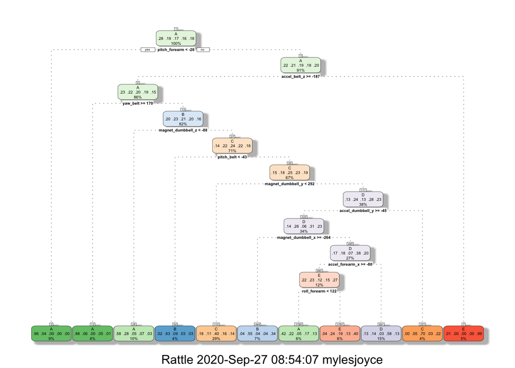

```r
fancyRpartPlot(model_ct$finalModel)
```

### Classification Tree Prediction

Now, I will predict my test set using the classification tree methodology.

```r
predict_ct <- predict(model_ct, my_test)
confusionMatrix(table(my_test$classe, predict_ct))
```

```
## Confusion Matrix and Statistics
##
##    predict_ct
##        A    B    C    D    E
##   A 1389   24  388  132   20
##   B  336  494  235  146  117
##   C   61   39  990   26   81
##   D  142   30  345  568   40
##   E   72  185  375  114  516
##
## Overall Statistics
##
##                Accuracy : 0.5764
##                  95% CI : (0.5646, 0.5881)
##     No Information Rate : 0.3398
##     P-Value [Acc > NIR] : < 2.2e-16
##
##                   Kappa : 0.4651
##
##  Mcnemar's Test P-Value : < 2.2e-16
##
## Statistics by Class:
##
##                      Class: A Class: B Class: C Class: D Class: E
## Sensitivity            0.6945  0.63990   0.4243  0.57606  0.66667
## Specificity            0.8841  0.86312   0.9543  0.90526  0.87752
## Pos Pred Value         0.7112  0.37199   0.8271  0.50489  0.40887
## Neg Pred Value         0.8756  0.94979   0.7631  0.92718  0.95395
## Prevalence             0.2913  0.11245   0.3398  0.14363  0.11275
## Detection Rate         0.2023  0.07196   0.1442  0.08274  0.07516
## Detection Prevalence   0.2845  0.19345   0.1744  0.16387  0.18383
## Balanced Accuracy      0.7893  0.75151   0.6893  0.74066  0.77210
```

An accuracy of 57.64%, YIKES. Back to the drawing board.

### Random Forest Model & Prediction

As classification trees provided such a low accuracy, the next more intensive methodology to be tested will be random forest.

```r
model_rf <- train(classe ~ ., data = my_train, method = "rf", trControl = control)
print(model_rf, digits = 4)
```

```
## Random Forest
##
## 12757 samples
##    51 predictor
##     5 classes: 'A', 'B', 'C', 'D', 'E'
##
## No pre-processing
## Resampling: Cross-Validated (3 fold)
## Summary of sample sizes: 8505, 8504, 8505
## Resampling results across tuning parameters:
##
##   mtry  Accuracy  Kappa
##    2    0.9846    0.9805
##   26    0.9878    0.9845
##   51    0.9831    0.9787
##
## Accuracy was used to select the optimal model using the largest value.
## The final value used for the model was mtry = 26.
```

```r
predict_rf <- predict(model_rf, my_test)
confusionMatrix(table(my_test$classe, predict_rf))
```

```
## Confusion Matrix and Statistics
##
##    predict_rf
##        A    B    C    D    E
##   A 1953    0    0    0    0
##   B   10 1311    6    0    1
##   C    0    7 1188    2    0
##   D    0    0    8 1115    2
##   E    0    0    1    4 1257
##
## Overall Statistics
##
##                Accuracy : 0.994
##                  95% CI : (0.9919, 0.9957)
##     No Information Rate : 0.2859
##     P-Value [Acc > NIR] : < 2.2e-16
##
##                   Kappa : 0.9924
##
##  Mcnemar's Test P-Value : NA
##
## Statistics by Class:
##
##                      Class: A Class: B Class: C Class: D Class: E
## Sensitivity            0.9949   0.9947   0.9875   0.9946   0.9976
## Specificity            1.0000   0.9969   0.9984   0.9983   0.9991
## Pos Pred Value         1.0000   0.9872   0.9925   0.9911   0.9960
## Neg Pred Value         0.9980   0.9987   0.9974   0.9990   0.9995
## Prevalence             0.2859   0.1920   0.1752   0.1633   0.1835
## Detection Rate         0.2845   0.1910   0.1731   0.1624   0.1831
## Detection Prevalence   0.2845   0.1934   0.1744   0.1639   0.1838
## Balanced Accuracy      0.9975   0.9958   0.9930   0.9965   0.9984
```

This model proves to be the best, as it has an accuracy of 99.4%. This means that the out-of-sample error rate is 0.006.

### Test Time

Below, you can see the random forest model’s predictions for the test set.

```r
predict(model_rf, test)
```

```
##  [1] B A B A A E D B A A B C B A E E A B B B
## Levels: A B C D E
```

### Acknowledgements

A big **THANK YOU** to the generous providers of the data for this project. Their information and more detail regarding the data can be found below:  
http://web.archive.org/web/20161224072740/http:/groupware.les.inf.puc-rio.br/har